# 05_Practical

Ryan Greenup 17805315

23 August 2019

# (Wk 5) Resampling Methods, Cross Validation and Bootstrapping

Material of Tue 2 April 2019, week 5

## Cross Validation

### (b) Fit a polynomial Regression

#### Plot the Data

##### base

First Visualise the data

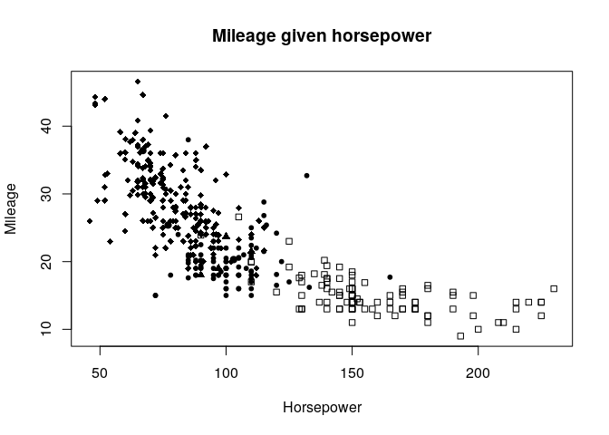

```r
plot(mpg ~ horsepower, data = Auto,
     pch = (15:25)[as.numeric(Auto$cylinders)],
     xlab = "Horsepower",
     ylab= "Mileage",
      main = "Mileage given horsepower")
```

##### ggplot2

First Visualise the data

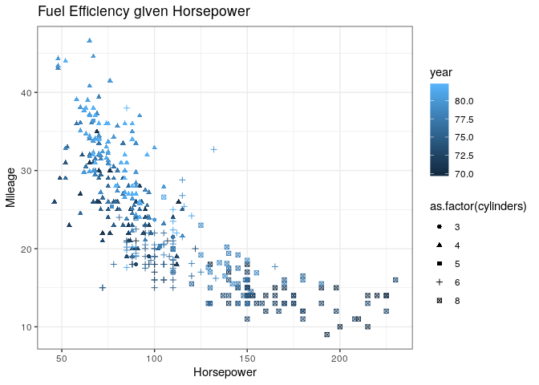

```r
ggplot(data = Auto, aes(y = mpg, x = horsepower, col = year, shape = as.factor(cylinders))) +
  geom_point() +
  theme_bw()+
  labs(x = "Horsepower", y = "Mileage", title = "Fuel Efficiency given Horsepower")
```

#### Conjecture a Model

Looking at the data we may find that the appropriate model is some non-linear function, given that we would expect $\frac{\Delta S}{\Delta E} \propto \frac{\Delta E}{\Delta t}, \quad \exists \bar{v}$ the appropriate model would be a hyperbola, however we will also try a quadratic function and compare the performance.

In a case like this it would be more appropriate to visualise the linearised data and then try and impute the correct corresponding model.

the `boot` package works with `glm` not `lm` so that needs to be used instead. If the `family` parameter of `glm` is not specified, the model produced will be a linear regression, it is also necessary in this case to use `poly` instead of `I()` (think changing heads in mathematica) so we can use a loop to change the degree of the polynomial later.

##### Hyperbola

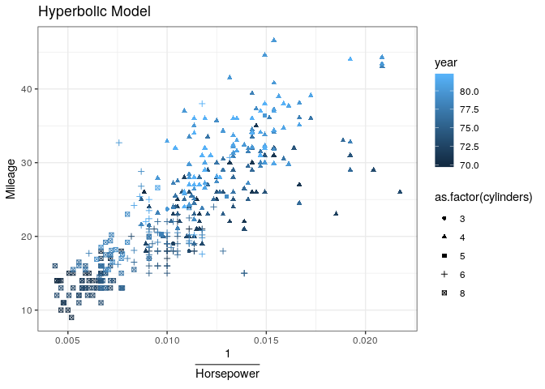

```r
ggplot(data = Auto, aes(y = mpg, x = I((horsepower)^-1), col = year, shape = as.factor(cylinders))) +
  geom_point() +
  theme_bw()+
  labs(x = TeX("$\\frac{1}{Horsepower}$"), y = "Mileage", title = "Hyperbolic Model")
```

##### Parabola

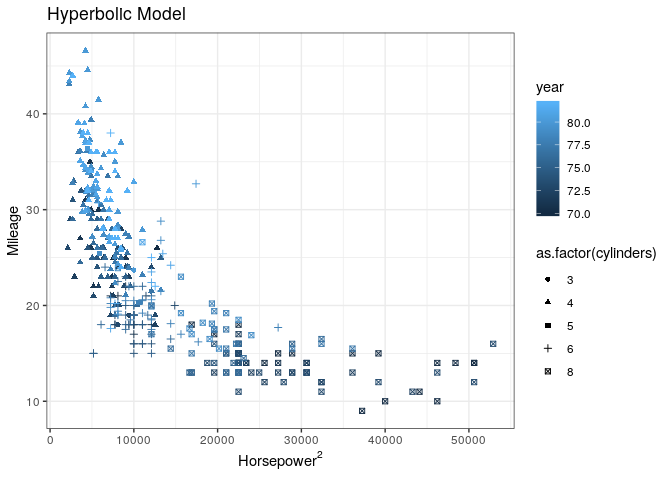

```r
ggplot(data = Auto, aes(y = mpg, x = I((horsepower)^2), col = year, shape = as.factor(cylinders))) +
  geom_point() +
  theme_bw()+
  labs(x = TeX("Horsepower$^2$"), y = "Mileage", title = "Hyperbolic Model")
```

##### Create the Models

These models suggest that the correct model is hyperbolic, although the plot appears to violate the assumption of homoskedasticity, this could however be explained by the cylinder count (denoted by shapes). Create both the models and plot them:

```r
mpg_mod_quad <- glm(formula = mpg ~ I(horsepower^2) + horsepower, data = Auto)
summary(mpg_mod_quad)$coefficients %>% round(1)
```

```
##                 Estimate Std. Error t value Pr(>|t|)
## (Intercept)         56.9        1.8    31.6        0
## I(horsepower^2)      0.0        0.0    10.1        0
## horsepower          -0.5        0.0   -15.0        0
```

```r
mpg_mod_hyp <- glm(formula = mpg ~ I(horsepower^-1), data = Auto)
summary(mpg_mod_hyp)$coefficients %>% round(1)
```

```
##                  Estimate Std. Error t value Pr(>|t|)
## (Intercept)           3.9        0.7     5.4        0
## I(horsepower^-1)   1813.0       64.9    28.0        0
```

#### Visualise the Model

##### Base

Now we overlay the model:

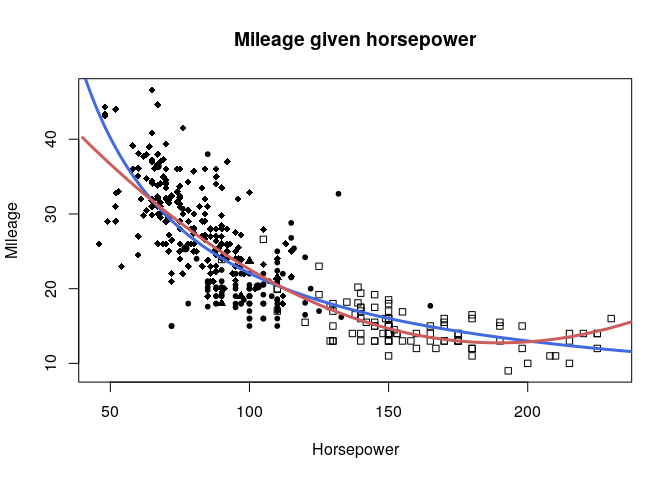

```r
# Plot the model
plot(mpg ~ horsepower, data = Auto,
     pch = (15:25)[as.numeric(Auto$cylinders)],
     xlab = "Horsepower",
     ylab= "Mileage",
      main = "Mileage given horsepower")

# Generate input data
newdata <- data.frame("horsepower" = seq(from = min(Auto$horsepower), to = max(Auto$horsepower), length.out = 1000))
newdata <- data.frame("horsepower" = seq(from = 40, to = 300, by = 1))

# Generate Predictions
predictionsquad <- predict(object = mpg_mod_quad, newdata = newdata)
predictionsdfquad <- data.frame("mpg" = predictionsquad, "horsepower" = newdata)

# Generate Predictions
predictionsquad <- predict(object = mpg_mod_quad, newdata = newdata)
predictionsdfquad <- data.frame("mpg" = predictionsquad, "horsepower" = newdata)


predictionshyp <- predict(object = mpg_mod_hyp, newdata = newdata)
predictionsdfhyp <- data.frame("mpg" = predictionshyp, "horsepower" = newdata)

# Overlay the Lines
lines(x = predictionsdfhyp$horsepower, y = predictionsdfhyp$mpg, col = "RoyalBlue", lwd = 3)
lines(x = predictionsdfquad$horsepower, y = predictionsdfquad$mpg, col = "IndianRed", lwd = 3)
```

##### ggplot2

Specifying legends for different models requires using `scale_color_discrete` [^1] or using scale_colour_manual and setting the colour inside `stat_smooth` to a string constant referenced inside `scale_color_manual`[^2]

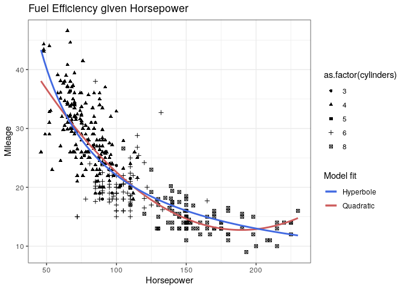

```r
ggplot(data = Auto, aes(y = mpg, x = horsepower)) +
  geom_point(aes(shape = as.factor(cylinders))) + # Specify the shape here so that the model isn't seperated by cylinders
  theme_bw()+
  labs(x = "Horsepower", y = "Mileage", title = "Fuel Efficiency given Horsepower") +
  stat_smooth(method = 'lm', formula = y ~ poly(x,2, raw = TRUE), aes(col = "Quadratic"), se = F) +
  stat_smooth(method = 'lm', formula = y ~ I(1/x), aes(col = "Hyperbole"), se = F) +
     scale_color_manual(name = "Model fit",
                        breaks = c("Hyperbole", "Quadratic"),
                        values = c("Hyperbole" = "RoyalBlue", "Quadratic" = "IndianRed"))
```

### (c) Use a validation set to select the best model

#### Seperate the Data

In order to use a validation set it is necessary to first randomly split the data into training and validation sets:

```r
Auto.train.index <- sample(nrow(Auto), size = nrow(Auto)/1.9) #don't set 2
  # If they are different sizes and theres an error in predict it is more likely
  # to be picked up if the validation set is a different size
Auto.train.df <- Auto[Auto.train.index, ]
Auto.val.df <- Auto[-Auto.train.index,]
```

#### Fit the Models

Now that the data has been seperated fit the models to the training data, observe that we need to `poly` instead of `I()` because later on we will wrap this in a loop and will need to specify a variable degree value (in this example degree is analogous to model flexibility).

```r
# There are two different ways to specify the training data, they both seem fine to me

## Quadratic
Auto.train.lmq <- glm(mpg ~ poly(horsepower, degree = 2, raw = TRUE), data = Auto, subset = Auto.train.index)
Auto.train.lmq <- glm(mpg ~ poly(horsepower, degree = 2, raw = TRUE), data = Auto.train.df)

## Hyperbolic
Auto.train.lmh <- glm(mpg ~ I((horsepower)^-1), data = Auto.train.df)

## Cubic
Auto.train.lmc <- glm(mpg ~ I((horsepower)^3), data = Auto.train.df)

# Create a list of models by order of degree, -1, 2, 3
Auto.models <- list(Auto.train.lmh, Auto.train.lmq, Auto.train.lmc)
```

##### Create a list

Later on we are going to want to grab these models, put them in a `list` to make life easy, use a `list` not a vector because:

1. It works with `lapply` and `sapply`
2. It makes more logical sense to put objects in a list and values in a vector

```r
# Create a list of models by order of degree, -1, 2, 3
Auto.models <- list(Auto.train.lmh, Auto.train.lmq, Auto.train.lmc)
```

#### Determine the error

In order to connect points accross factors, it is necessary to tell `ggplot` to treat the seperate values as one group by specifying `aes(group = DataSet)` inside the initial mapping [^3], it will also be necessary to **g**enerate **levels** for the model names by using `gl` so that the order is respected by `ggplot` (I’ve presumed that a hyperbola is less flexible than a quadratic in this case because the limits have been tied to $0/\infty$ unlike the paraola).

##### Create the list of models

It is necessary to specify the order of the models so

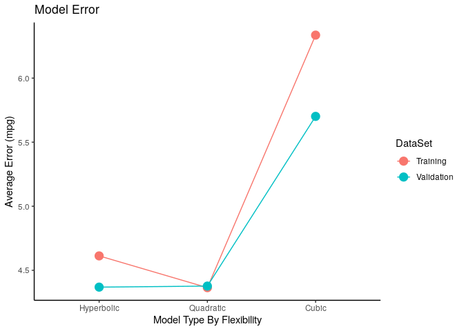

```r
# Create the list of models, it is necessary to specify order because
  # so that we can use a line plot
    # A hyperbola has only one point of inflection, a parabola two and a cubic three, this is a good measurement of flexibility
# Create a Data Frame



ModelType <- c("Hyperbolic", "Quadratic", "Cubic")
ModelType <- gl(n = 3, length = 3, ordered = TRUE, labels = c("Hyperbolic", "Quadratic", "Cubic"), k = 1)

Auto.train.Loss <- data.frame("ModelType" = ModelType, "Training" = rep(NA, length.out = 3), "Validation" = rep(NA, length.out = 3))



Auto.train.Loss <- data.frame(ModelType, "Training" = rep(NA, length.out = 3), "Validation" = rep(NA, length.out = 3))


#Create an Error Function
trainingrmse <- function(model){
  sqrt(mean((Auto.train.df$mpg - predict(model))^2))
}


validationrmse <- function(model){
  preds <- predict(object = model, Auto.val.df )
  sqrt(mean((Auto.val.df$mpg - preds)^2))
}

# Assign the values
Auto.train.Loss$Training <- sapply(Auto.models, trainingrmse)
Auto.train.Loss$Validation <- sapply(Auto.models, validationrmse)


# Convert from Wide to long, melt is outdated use tidry::gather() and tidyr::spread()
  # Maybe I should try making them tibbles?
Auto.train.Loss.tidy <-
Auto.train.Loss %>%
  gather(Training, Validation, key = "DataSet", value = "RMSE" )

#I used to do this like so, but this is deprecated for tidyverse
  #melt(data = Auto.train.Loss, id.vars = "ModelType", measure.vars = c("Training", "Validation"))


ggplot(Auto.train.Loss.tidy, aes(x = ModelType, y = RMSE, col = DataSet, fill = DataSet, group = DataSet)) +
  geom_line() +
  geom_point(size = 4) +
  theme_classic() +
  labs(title = "Model Error", x = "Model Type By Flexibility", y = "Average Error (mpg)")
```

The unduly high performance of the quadratic model on the training data may be indiciative of high model bias, in conjustion with the very slightly higher validation error, the appropriate model would be the hyperbolic model.

This could however be because the hyperbola was specified to the model such that $x \rightarrow 0 \implies y \rightarrow \infty$ whereas the parabola was given more flexibility, however a parabola cannot have this as a fundamental property so this is perhaps more evidence to support the hyperbolic model.

### (d) Compare different Seeds

Different seed values create different models and error plots, although, they all have a similar characteristic:

#### Seed as 5

```
## [[1]]
##    ModelType    DataSet     RMSE
## 1 Hyperbolic   Training 4.647031
## 2  Quadratic   Training 4.570993
## 3      Cubic   Training 6.289877
## 4 Hyperbolic Validation 4.354552
## 5  Quadratic Validation 4.130246
## 6      Cubic Validation 5.716326
##
## [[2]]
```

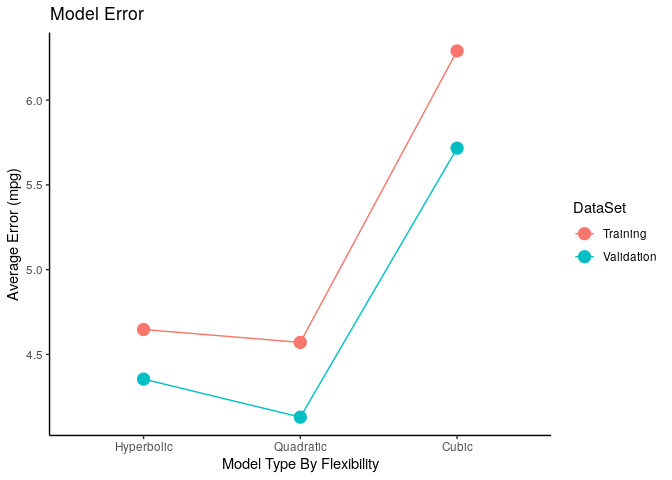

```r
validationplot <- function(seed){

set.seed(seed) # Set the seed such that we might have

Auto.train.index <- sample(nrow(Auto), size = nrow(Auto)/1.9) #don't set 2
  # If they are different sizes and theres an error in predict it is more likely
  # to be picked up if the validation set is a different size
Auto.train.df <- Auto[Auto.train.index, ]
Auto.val.df <- Auto[-Auto.train.index,]


## Quadratic
Auto.train.lmq <- glm(mpg ~ poly(horsepower, degree = 2, raw = TRUE), data = Auto.train.df)

## Hyperbolic
Auto.train.lmh <- glm(mpg ~ I((horsepower)^-1), data = Auto.train.df)

## Cubic
Auto.train.lmc <- glm(mpg ~ I((horsepower)^3), data = Auto.train.df)

# Create a list of models by order of degree, -1, 2, 3
Auto.models <- list(Auto.train.lmh, Auto.train.lmq, Auto.train.lmc)

# Create the list of models, it is necessary to specify order because
  # so that we can use a line plot
    # A hyperbola has only one point of inflection, a parabola two and a cubic three, this is a good measurement of flexibility
# Create a Data Frame



ModelType <- c("Hyperbolic", "Quadratic", "Cubic")
ModelType <- gl(n = 3, length = 3, ordered = TRUE, labels = c("Hyperbolic", "Quadratic", "Cubic"), k = 1)

Auto.train.Loss <- data.frame("ModelType" = ModelType, "Training" = rep(NA, length.out = 3), "Validation" = rep(NA, length.out = 3))



Auto.train.Loss <- data.frame(ModelType, "Training" = rep(NA, length.out = 3), "Validation" = rep(NA, length.out = 3))


#Create an Error Function
trainingrmse <- function(model){
  sqrt(mean((Auto.train.df$mpg - predict(model))^2))
}


validationrmse <- function(model){
  preds <- predict(object = model, Auto.val.df )
  sqrt(mean((Auto.val.df$mpg - preds)^2))
}

# Assign the values
Auto.train.Loss$Training <- sapply(Auto.models, trainingrmse)
Auto.train.Loss$Validation <- sapply(Auto.models, validationrmse)


# Convert from Wide to long, melt is outdated use tidry::gather() and tidyr::spread()
  # Maybe I should try making them tibbles?
Auto.train.Loss.tidy <-
Auto.train.Loss %>%
  gather(Training, Validation, key = "DataSet", value = "RMSE" )

#I used to do this like so, but this is deprecated for tidyverse
  #melt(data = Auto.train.Loss, id.vars = "ModelType", measure.vars = c("Training", "Validation"))


p <- ggplot(Auto.train.Loss.tidy, aes(x = ModelType, y = RMSE, col = DataSet, fill = DataSet, group = DataSet)) +
  geom_line() +
  geom_point(size = 4) +
  theme_classic() +
  labs(title = "Model Error", x = "Model Type By Flexibility", y = "Average Error (mpg)")


return(list(Auto.train.Loss.tidy, p))

}

validationplot(5)
```

#### Seed as 8

```
## [[1]]
##    ModelType    DataSet     RMSE
## 1 Hyperbolic   Training 4.574275
## 2  Quadratic   Training 4.340869
## 3      Cubic   Training 6.017756
## 4 Hyperbolic Validation 4.442989
## 5  Quadratic Validation 4.406957
## 6      Cubic Validation 6.077114
##
## [[2]]
```

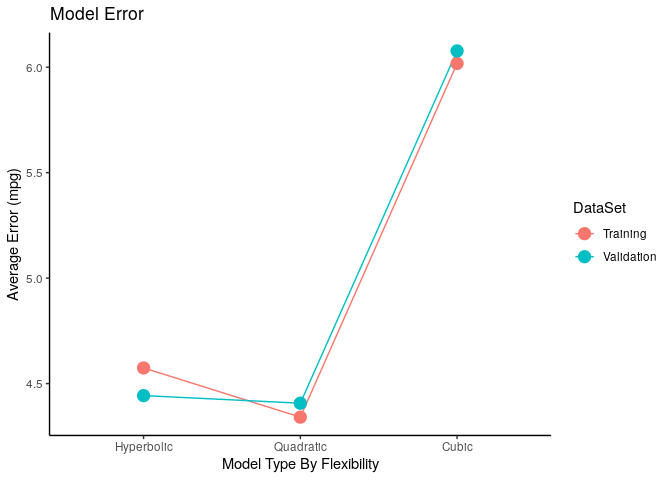

```r
validationplot(8)
```

#### Many Seeds

This following clearly shows that the quadratic model performs significantly better on the validation data than the Cubic and marginally better than the hyperbolic.

```r
gensplits <- function(n){
## This dynamic method is slow, instead you should staitcally allocate to a data frame.

#Set a vectory to grow
valplots <- cbind(validationplot(1)[[1]], "seed" = as.factor(1)) # Dynamic bad

# Fill it with a loop
for (i in 1:10) {
valplots <- rbind(valplots,cbind(validationplot(i)[[1]], "seed" = as.factor(i)))
}

# Now pull out the training data plots, theyll make this look like a mess
## Base
valplots <- valplots[valplots$DataSet == "Validation",]
valplots <- valplots[,c(1, 3, 4)]
return(valplots)
}




# In case you want to plot multiple lines at once, you should specify `group=variableWhichDefinesLines'

splot <- ggplot(gensplits(10), aes(x = ModelType, y = RMSE, col = seed, group = seed)) +
  geom_line() +
  geom_point(size = 3) +
  theme_classic() +
  labs(title = "Model Error", x = "Model Type By Flexibility", y = "Average Error (mpg)")
```

##### Scatterplot

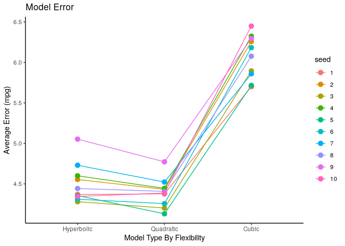

```r
splot
```

##### BoxPlot

What’s powerful about this is that we can do many many splits and use that to determine which is the best model, Although at this stage we might as well have just used **Leave One Out CV**

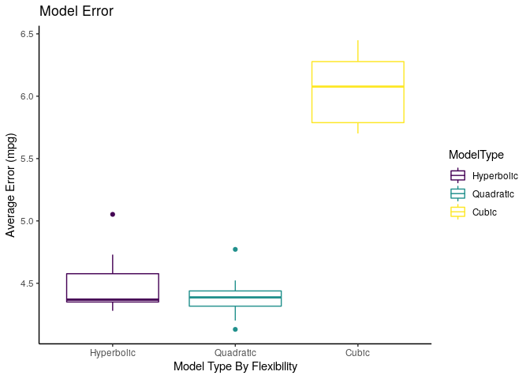

```r
ggplot(gensplits(10000), aes(x = ModelType, y = RMSE, col = ModelType)) +
  geom_boxplot() +
  theme_classic() +
  labs(title = "Model Error", x = "Model Type By Flexibility", y = "Average Error (mpg)")
```

### (e) What are the disadvantages

The disadvantages to using a straight data split are:

- The validation errors are sensitive to the split taken
- The validation errors will often be overestimated because there is less data for the model to be fit to
  - That is to say, when the model is actually used it will be made with all the data so it will perform better

### (f) Use the LOOCV method for the above model

#### Write a program from first principles

```r
# Create a Function to Perform Leave One Out CV

LeaveOneOut <- function(formula, data){
  MSE <- 0 #Empty Value to build during Loop
  for (i in 1:nrow(data)) {
    data_LO <- data[-i,]  # This is Left Out Value
    model   <- lm(formula, data = data_LO)  #Build the Model
    pred    <- predict(object = model, newdata = data[i,]) #This is the modelled value
    D_MSE   <- (1/nrow(data))*((pred - data$mpg[i])^2) # This is the change in MSE
    MSE     <- MSE + D_MSE #This is the MSE
  }
  return(data.frame("RSS" = nrow(data)*MSE, "MSE" = MSE, "RMSE" = sqrt(MSE))) #Return Errors
}

# Feed a list to the function with sapply

mymods <- list(
  "HyperBolic" = mpg ~ I(1/horsepower),
  "Linear"     = mpg ~ I(horsepower),
  "Quadratic"  = mpg ~ I(horsepower^2) + horsepower,
  "Cubic"      = mpg ~ poly(x = horsepower, degree = 3, raw = TRUE)
  )


# So when mapping with sapply, use a function to make the parameter constant
    # (In mathematica you would use a pure function with #)

LOOCV_Error <- sapply(X = mymods,
                     FUN = function(x){
                       LeaveOneOut(x, data = Auto)
                       }
                 )
```

##### Plot the Data

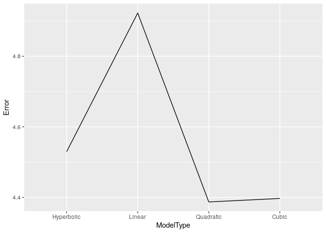

```r
LOOCV_Error2 <- gl(n = ncol(LOOCV_Error), k = 4, length = ncol(LOOCV_Error), labels = c("Hyperbolic", "Linear", "Quadratic", "Cubic"), ordered = TRUE)

 LOOCV_Error_tidy <-as.data.frame( LOOCV_Error[3, ])
 LOOCV_Error_tidy <- gather(data = LOOCV_Error_tidy, key = ModelType, value = Error)

LOOCV_Error_tidy$ModelType <- factor(x = c("Hyperbolic", "Linear", "Quadratic", "Cubic"),
                                       levels = c("Hyperbolic", "Linear", "Quadratic", "Cubic"),
                                       labels = c("Hyperbolic", "Linear", "Quadratic", "Cubic"),
                                       ordered = TRUE, nmax = 4
                                       )



 ggplot(LOOCV_Error_tidy, aes(x = ModelType, y = Error, group = 1)) +
   geom_line()
```

#### Use the `boot` library.

So let’s consider polynomial models and take flexiility as a positive function of degree

```r
# Consider how many models?
n <- 6

# Create an empty vector
    #Static Vector executes way quikcer
errors_LOO <- rep(0, n)

# Fill the vector with polynomials
  # use glm not lm because the `boot` package only works with
for (i in 1:n) {
CrValLOOMod <- model <- glm(mpg ~ poly(x = horsepower, degree = i, raw = TRUE), data = Auto)
# Not specifying k sets default as n-1 LeaveOneOut
errors_LOO[i] <- cv.glm(data = Auto, glmfit = CrValLOOMod)$delta[1]
}

errors_LOO_df <- data.frame("Degree" = as.factor(1:n), " Error_MSE" = errors_LOO)
names(errors_LOO_df) <- c("Degree", "Error_MSE")
```

##### Plot the Errors

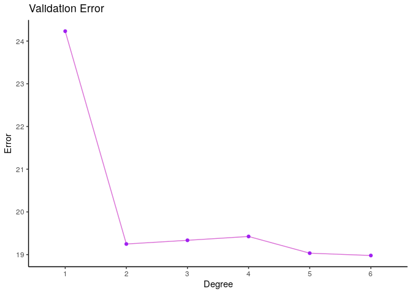

```r
ggplot(errors_LOO_df, aes(x = Degree, y = Error_MSE, group = 1)) +
  geom_line(col = "orchid") +
  geom_point(col = "Purple") +
  theme_classic() +
  labs(x = "Degree", y = "Error", title = "Validation Error")
```

### Use $k$-fold Cross Validation Method for the same model

```r
# How many polynomials to consider
n <- 6

# Create an empty vector
kfold_Error <- rep(NA, n)

# Use a loop to generate the errors

for (i in 1:6) {
  kfoldmod <- glm(mpg ~ poly(x = horsepower, degree = i, raw = TRUE), data = Auto)
  kfold_Error[i] <- cv.glm(data = Auto, glmfit = kfoldmod, K = 10)$delta[1]
    # The second returned value is the analytic solution that only works for polynomials
      # regardless it still determines the actual value so we'll use whatever
}

kfold_Error_df <- data.frame("Degree" = as.factor(1:n), "Error" = kfold_Error)
```

#### Plot the Errors

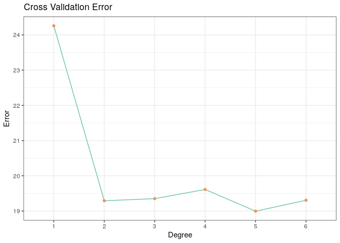

```r
cols <- brewer.pal(3, name = "Set2")
ggplot(kfold_Error_df, aes(x = Degree, y = Error, group = 1)) +
  geom_line(col = cols[1]) +
  geom_point(col = cols[2]) +
  theme_bw() +
  labs(x = "Degree", y = "Error", title = "Cross Validation Error")
```

This again suggests that the appropriate model, given considerations of bias and variance, is the second degree polynomial.

### (h) Conclusion

The appropriate model, given $k$-**fold** CV, **Leave One Out** CV and a validation split is a second degree polynomial.

Other models should be considered as as overparameterised because they do not perform significantly better on validation data, these models would tend towards high variance rather than bias.

## Boot Strapping

### (a) Generate 20 random numbers

```r
results <- rnorm(20, mean = 140, sd = 10)
```

### (b) Determine the mean value

The mean value is 138.72 calculated by using the `mean()` function

### (c) Generate 1000 bootstrap samples using the above dataset

#### Using the `boot` packages

Using the `boot` package requires setting up a function that represents the statistic of interest with variables `data` and `index`, then the bootstrap can be called using that function to specify the statistic of concern.

```r
myfun <- function(data, index) mean(data[index])

boot(data = results, R = 1000, statistic = myfun)
```

```
##
## ORDINARY NONPARAMETRIC BOOTSTRAP
##
##
## Call:
## boot(data = results, statistic = myfun, R = 1000)
##
##
## Bootstrap Statistics :
##     original     bias    std. error
## t1* 138.7174 0.00376757    2.008606
```

#### Function from First Principles

```r
n <- 10000
dynlist <- list()

samples <- rep(NA, 20)

for (j in 1:n) {
  for (i in 1:length(results)) {
    samples[i] <- results[round(runif(1, min = 1, max = length(results)))]
  }
  dynlist[[j]] <- samples
}

# Now that we have a list of samples, we may take the observed parameters in the samples drawn from the samples

for (i in 1:length(dynlist)) {
 dynlist[["meanvals"]][i] <- mean(dynlist[[i]])
 dynlist[["medvals"]][i]  <- median(dynlist[[i]])
 dynlist[["sdvals"]][i]    <- sd(dynlist[[i]])
}

# Now that we have taken the samples, average those and we have the values

 dynlist[["mean"]]  <- mean(dynlist[["meanvals"]]) %>% print()
```

```
## [1] 138.25
```

```r
 dynlist[["mode"]]  <- mean(dynlist[["medvals"]]) %>% print()
```

```
## [1] 137.002
```

```r
 dynlist[["sd"]]    <- mean(dynlist[["sdvals"]]) %>% print()
```

```
## [1] 8.627162
```

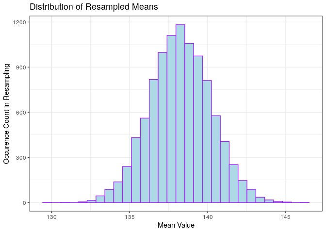

```r
 ggplot(data = as_tibble(dynlist[["meanvals"]]), aes(x = value)) +
   geom_histogram(col = "Purple", fill = "LightBlue") +
   theme_bw() +
   labs(x = "Mean Value", y = "Occurence Count in Resampling", title = "Distribution of Resampled Means")
```

**Toggle answer**

*How to Fold Things*

```r
  summary(cars)
```

[output not shown]

[^1]: [Data Visualization with ggplot2 (Part 2) by William Surles](https://rstudio-pubs-static.s3.amazonaws.com/295930_27a91f861d5a4aad89b35ea757e8eedd.html#%E2%80%93_sum)
[^2]: [Ariel Mundoon, Creating legends when aesthetics are constants in ggplot2](https://aosmith.rbind.io/2018/07/19/manual-legends-ggplot2/)
[^3]: [Connecting Points in `ggplot2`](https://stackoverflow.com/a/8617377/10593632)